# Statistics

## Summary

- `ggplot()` specifies what data to use and what variables will be mapped to where
- inside `ggplot()`, `aes(x = , y = , color = )` specify what variables correspond to what aspects of the plot in general
- layers of plots can be combined using the `+` at the **end** of lines
- use `geom_line()` and `geom_point()` to add lines and points
- sometimes you need to add a `group` element to `aes()` if your plot looks strange
- make sure you are plotting what you think you are by checking the numbers!
- `facet_grid(~variable)` and `facet_wrap(~variable)` can be helpful to quickly split up your plot

## Summary

- the factor class allows us to have a different order from alphanumeric for categorical data
- we can change data to be a factor variable using `mutate()`, `as_factor()` (in the `forcats` package), or `factor()` functions and specifying the levels with the `levels` argument
- `fct_reorder({variable_to_reorder}, {variable_to_order_by})` helps us reorder a variable by the values of another variable
- arranging, tabulating, and plotting the data will reflect the new order

## Overview

We will cover how to use R to compute some of basic statistics and fit some basic statistical models.

- Correlation
- T-test
- Linear Regression / Logistic Regression

[figure not shown]

## Overview

We will focus on how to use R software to do these. We will be glossing over the statistical **theory** and “formulas” for these tests. Moreover, we do not claim the data we use for demonstration meet **assumptions** of the methods.

There are plenty of resources online for learning more about these methods.

Check out [www.opencasestudies.org](https://www.opencasestudies.org/) for deeper dives on some of the concepts covered here and the [resource page](https://daseh.org/resources.html) for more resources.

## Correlation

## Correlation

The correlation coefficient is a summary statistic that measures the strength of a linear relationship between two numeric variables.

- The strength of the relationship - based on how well the points form a line
- The direction of the relationship - based on if the points progress upward or downward

[figure not shown]

[source](https://www.mathsisfun.com/data/correlation.html)

See this [case study](https://www.opencasestudies.org/ocs-bp-co2-emissions/#Data_Analysis) for more information.

## Correlation

Function `cor()` computes correlation in R.

```
cor(x, y = NULL, use = c("everything", "complete.obs"),
    method = c("pearson", "kendall", "spearman"))
```

- provide two numeric vectors of the same length (arguments `x`, `y`), or
- provide a data.frame / tibble with numeric columns only
- by default, Pearson correlation coefficient is computed

## Correlation test

Function `cor.test()` also computes correlation and tests for association.

```
cor.test(x, y = NULL, alternative(c("two.sided", "less", "greater")),
    method = c("pearson", "kendall", "spearman"))
```

- provide two numeric vectors of the same length (arguments `x`, `y`), or
- provide a data.frame / tibble with numeric columns only
- by default, Pearson correlation coefficient is computed
- alternative values:
  - two.sided means true correlation coefficient is not equal to zero (default)
  - greater means true correlation coefficient is > 0 (positive relationship)
  - less means true correlation coefficient is < 0 (negative relationship)

## GUT CHECK!

What class of data do you need to calculate a correlation?

A. Character data

B. Factor data

C. Numeric data

## Correlation

Let’s look at the dataset of yearly CO2 emissions by country.

```r
yearly_co2 <-
  read_csv(file = "https://daseh.org/data/Yearly_CO2_Emissions_1000_tonnes.csv")
```

## Correlation for two vectors

First, we create two vectors.

```r
# x and y must be numeric vectors
y1980 <- yearly_co2 |> pull(`1980`)
y1985 <- yearly_co2 |> pull(`1985`)
```

Like other functions, if there are `NA`s, you get `NA` as the result. But if you specify `use = "complete.obs"`, then it will give you correlation using the non-missing data.

```r
cor(y1980, y1985, use = "complete.obs")
```

```
[1] 0.9936257
```

## Correlation coefficient calculation and test

```r
cor.test(y1980, y1985)
```

```
    Pearson's product-moment correlation

data:  y1980 and y1985
t = 114.59, df = 169, p-value < 0.00000000000000022
alternative hypothesis: true correlation is not equal to 0
95 percent confidence interval:
 0.9913844 0.9952853
sample estimates:
      cor
0.9936257
```

## Broom package

The `broom` package helps make stats results look tidy

```r
library(broom)
cor_result <- tidy(cor.test(y1980, y1985))
glimpse(cor_result)
```

```
Rows: 1
Columns: 8
$ estimate    <dbl> 0.9936257
$ statistic   <dbl> 114.5851
$ p.value     <dbl> 0.00000000000000000000000000000000000000000000000000000000…
$ parameter   <int> 169
$ conf.low    <dbl> 0.9913844
$ conf.high   <dbl> 0.9952853
$ method      <chr> "Pearson's product-moment correlation"
$ alternative <chr> "two.sided"
```

## Correlation for two vectors with plot

In plot form… `geom_smooth()` and `annotate()` can look very nice!

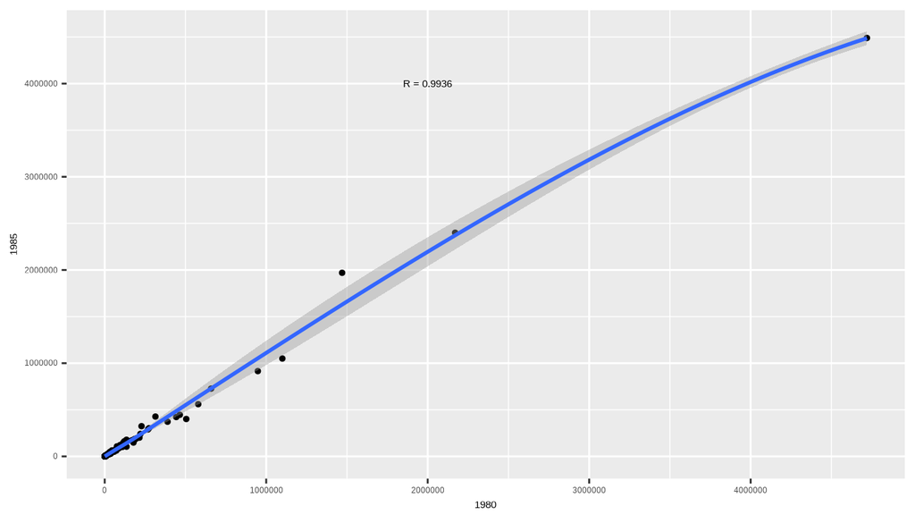

```r
corr_value <- pull(cor_result, estimate) |> round(digits = 4)
cor_label <- paste0("R = ", corr_value)
yearly_co2 |>
  ggplot(aes(x = `1980`, y = `1985`)) + geom_point(size = 1) + geom_smooth() +
  annotate("text", x = 2000000, y = 4000000, label = cor_label)
```

## Correlation for data frame columns

We can compute correlation for all pairs of columns of a data frame / matrix. This is often called, *“computing a correlation matrix”*.

Columns must be all numeric!

```r
co2_subset <- yearly_co2 |>
  select(c(`1950`, `1980`, `1985`, `2010`))

head(co2_subset)
```

```
# A tibble: 6 × 4
  `1950` `1980` `1985` `2010`
   <dbl>  <dbl>  <dbl>  <dbl>
1   84.3   1760   3510   8460
2  297     5170   7880   4600
3 3790    66500  72800 119000
4   NA       NA     NA    517
5  187     5350   4700  29100
6   NA      143    249    524
```

## Correlation for data frame columns

We can compute correlation for all pairs of columns of a data frame / matrix. This is often called, *“computing a correlation matrix”*.

```r
cor_mat <- cor(co2_subset, use = "complete.obs")
cor_mat
```

```
          1950      1980      1985      2010
1950 1.0000000 0.9228253 0.8818288 0.5415047
1980 0.9228253 1.0000000 0.9935477 0.7270839
1985 0.8818288 0.9935477 1.0000000 0.7827256
2010 0.5415047 0.7270839 0.7827256 1.0000000
```

## Correlation for data frame columns with plot

`corrplot` package can make correlation matrix plots

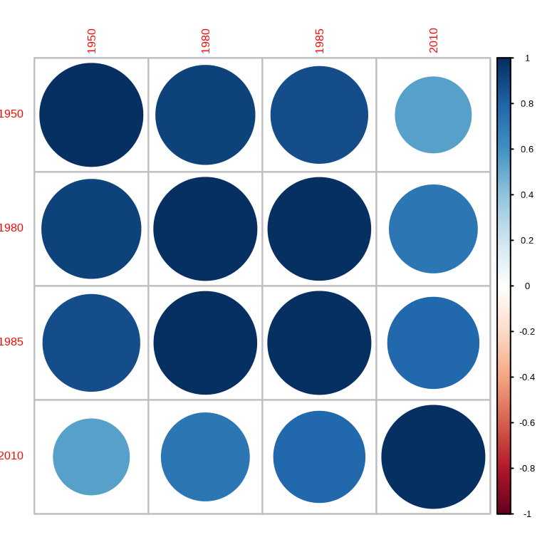

```r
library(corrplot)
corrplot(cor_mat)
```

## Correlation does not imply causation

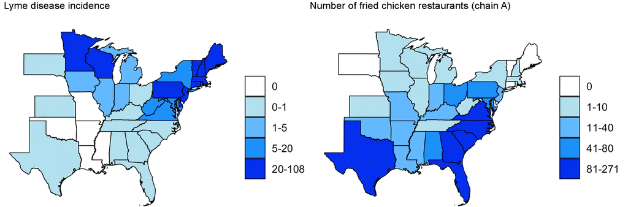

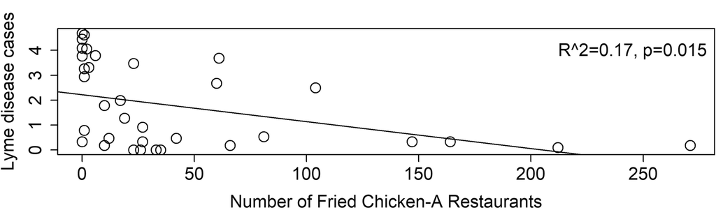

[source](http://doi.org/10.1007/s10393-020-01472-1)

## T-test

## T-test

The commonly used t-tests are:

- **one-sample t-test** – used to test mean of a variable in one group
- **two-sample t-test** – used to test difference in means of a variable between two groups
  - if the “two groups” are data of the *same* individuals collected at 2 time points, we say it is two-sample paired t-test)

The `t.test()` function does both.

```
t.test(x, y = NULL,
       alternative = c("two.sided", "less", "greater"),
       mu = 0, paired = FALSE, var.equal = FALSE,
       conf.level = 0.95, ...)
```

## Running one-sample t-test

It tests the mean of a variable in one group. By default (i.e., without us explicitly specifying values of other arguments):

- tests whether a mean of a variable is equal to 0 (`mu = 0`)
- uses “two sided” alternative (`alternative = "two.sided"`)
- returns result assuming confidence level 0.95 (`conf.level = 0.95`)
- omits `NA` values in data

Let’s look at the CO2 emissions data again.

```r
t.test(y1980)
```

```
    One Sample t-test

data:  y1980
t = 3.3324, df = 170, p-value = 0.001056
alternative hypothesis: true mean is not equal to 0
95 percent confidence interval:
  44745.81 174792.25
sample estimates:
mean of x
   109769
```

## Running two-sample t-test

It tests the difference in means of a variable between two groups. By default:

- tests whether difference in means of a variable is equal to 0 (`mu = 0`)
- uses “two sided” alternative (`alternative = "two.sided"`)
- returns result assuming confidence level 0.95 (`conf.level = 0.95`)
- assumes data are not paired (`paired = FALSE`)
- assumes true variance in the two groups is not equal (`var.equal = FALSE`)
- omits `NA` values in data

Check out this this [case study](https://www.opencasestudies.org/ocs-bp-rural-and-urban-obesity/#Data_Analysis) and this [case study](https://www.opencasestudies.org/ocs-bp-diet/#Data_Analysis) for more information.

## Running two-sample t-test in R

```r
t.test(y1980, y1985)
```

```
    Welch Two Sample t-test

data:  y1980 and y1985
t = -0.090533, df = 341, p-value = 0.9279
alternative hypothesis: true difference in means is not equal to 0
95 percent confidence interval:
 -95902.79  87462.97
sample estimates:
mean of x mean of y
 109769.0  113988.9
```

## T-test: retrieving information from the result with `broom` package

The `broom` package has a `tidy()` function that can organize results into a data frame so that they are easily manipulated (or nicely printed)

```r
result <- t.test(y1980, y1985)
result_tidy <- tidy(result)
glimpse(result_tidy)
```

```
Rows: 1
Columns: 10
$ estimate    <dbl> -4219.909
$ estimate1   <dbl> 109769
$ estimate2   <dbl> 113988.9
$ statistic   <dbl> -0.09053303
$ p.value     <dbl> 0.9279168
$ parameter   <dbl> 340.999
$ conf.low    <dbl> -95902.79
$ conf.high   <dbl> 87462.97
$ method      <chr> "Welch Two Sample t-test"
$ alternative <chr> "two.sided"
```

## P-value adjustment

You run an increased risk of Type I errors (a “false positive”) when multiple hypotheses are tested simultaneously.

Use the `p.adjust()` function on a vector of p values. Use `method =` to specify the adjustment method:

```r
my_pvalues <- c(0.049, 0.001, 0.31, 0.00001)
p.adjust(my_pvalues, method = "BH") # Benjamini Hochberg
```

```
[1] 0.06533333 0.00200000 0.31000000 0.00004000
```

```r
p.adjust(my_pvalues, method = "bonferroni") # multiply by number of tests
```

```
[1] 0.19600 0.00400 1.00000 0.00004
```

```r
my_pvalues * 4
```

```
[1] 0.19600 0.00400 1.24000 0.00004
```

See [here](https://www.nature.com/articles/nbt1209-1135) for more about multiple testing correction. Bonferroni also often done as p value threshold divided by number of tests (0.05/test number).

## Some other statistical tests

- `wilcox.test()` – Wilcoxon signed rank test, Wilcoxon rank sum test
- `shapiro.test()` – Test normality assumptions
- `ks.test()` – Kolmogorov-Smirnov test
- `var.test()`– Fisher’s F-Test
- `chisq.test()` – Chi-squared test
- `aov()` – Analysis of Variance (ANOVA)

## Summary

- Use `cor()` to calculate correlation between two vectors, `cor.test()` can give more information.
- `corrplot()` is nice for a quick visualization!
- `t.test()` one sample test to test the difference in mean of a single vector from zero (one input)
- `t.test()` two sample test to test the difference in means between two vectors (two inputs)
- `tidy()` in the `broom` package is useful for organizing and saving statistical test output
- Remember to adjust p-values with `p.adjust()` when doing multiple tests on data

## Lab Part 1

🏠 [Class Website](https://daseh.org/)

💻 [Lab](https://daseh.org/modules/Statistics/lab/Statistics_Lab.Rmd)

## Regression

## Linear regression

Linear regression is a method to model the relationship between a response and one or more explanatory variables.

Most commonly used statistical tests are actually specialized regressions, including the two sample t-test, see here for more.

## Linear regression notation

Here is some of the notation, so it is easier to understand the commands/results.

\[ y_i = \alpha + \beta x_{i} + \varepsilon_i \] where:

- \(y_i\) is the outcome for person i
- \(\alpha\) is the intercept
- \(\beta\) is the slope (also called a coefficient) - the mean change in y that we would expect for one unit change in x (“rise over run”)
- \(x_i\) is the predictor for person i
- \(\varepsilon_i\) is the residual variation for person i

## Linear regression

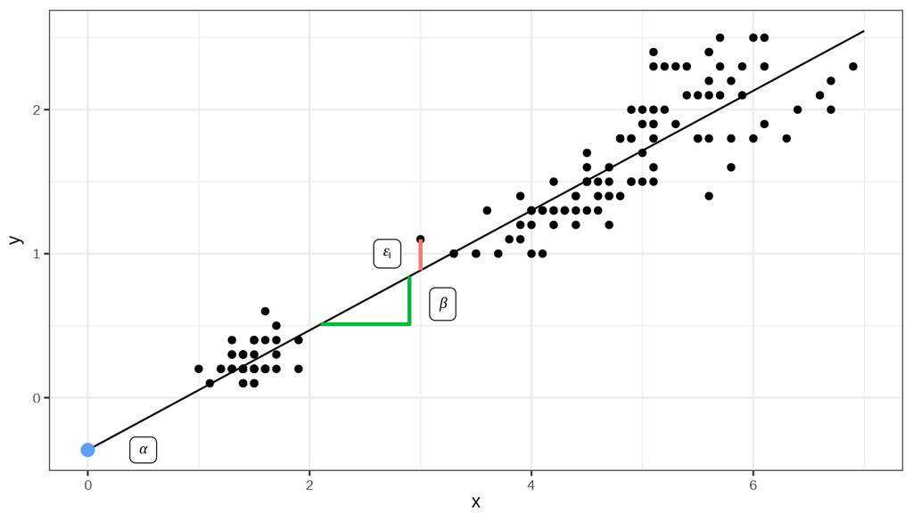

## Linear regression

Linear regression is a method to model the relationship between a response and one or more explanatory variables.

We provide a little notation here so some of the commands are easier to put in the proper context.

\[ y_i = \alpha + \beta_1 x_{i1} + \beta_2 x_{i2} + \beta_3 x_{i3} + \varepsilon_i \] where:

- \(y_i\) is the outcome for person i
- \(\alpha\) is the intercept
- \(\beta_1\), \(\beta_2\), \(\beta_2\) are the slopes/coefficients for variables \(x_{i1}\), \(x_{i2}\), \(x_{i3}\) - average difference in y for a unit change (or each value) in x while accounting for other variables
- \(x_{i1}\), \(x_{i2}\), \(x_{i3}\) are the predictors for person i
- \(\varepsilon_i\) is the residual variation for person i

See this [case study](https://www.opencasestudies.org/ocs-bp-diet/#Data_Analysis) for more details.

## Linear regression fit in R

To fit regression models in R, we use the function `glm()` (Generalized Linear Model).

You may also see `lm()` which is a more limited function that only allows for normally/Gaussian distributed error terms (aka typical linear regressions).

We typically provide two arguments:

- `formula` – model formula written using names of columns in our data
- `data` – our data frame

## Linear regression fit in R: model formula

Model formula \[ y_i = \alpha + \beta x_{i} + \varepsilon_i \] In R translates to

`y ~ x`

## Linear regression fit in R: model formula

Model formula \[ y_i = \alpha + \beta x_{i} + \varepsilon_i \] In R translates to

`y ~ x`

In practice, `y` and `x` are replaced with the **names of columns from our data set**.

For example, if we want to fit a regression model where outcome is `income` and predictor is `years_of_education`, our formula would be:

`income ~ years_of_education`

## Linear regression fit in R: model formula

Model formula \[ y_i = \alpha + \beta_1 x_{i1} + \beta_2 x_{i2} + \beta_3 x_{i3} + \varepsilon_i \] In R translates to

`y ~ x1 + x2 + x3`

In practice, `y` and `x1`, `x2`, `x3` are replaced with the **names of columns from our data set**.

For example, if we want to fit a regression model where outcome is `income` and predictors are `years_of_education`, `age`, and `location` then our formula would be:

`income ~ years_of_education + age + location`

## Linear regression example

Let’s look variables that might be able to predict the number of heat-related ER visits in Colorado.

We’ll use the dataset that has ER visits separated out by age category.

We’ll combine this with a new dataset that has some weather information about summer temperatures in Denver, downloaded from https://www.weather.gov/bou/DenverSummerHeat.

We will use this as a proxy for temperatures for the state of CO as a whole for this example.

## Linear regression example

```r
er <- read_csv(file = "https://daseh.org/data/CO_ER_heat_visits_by_age.csv")

temps <- read_csv(file = "https://daseh.org/data/Denver_heat_data.csv")

er_temps <- full_join(er, temps)
er_temps
```

```
# A tibble: 60 × 8
    year age      rate lower95cl upper95cl visits highest_temp no_days_above_100
   <dbl> <chr>   <dbl>     <dbl>     <dbl>  <dbl>        <dbl>             <dbl>
 1  2011 0-4 ye…  3.52      1.82      6.16     12           98                 0
 2  2011 15-34 …  7.34      5.95      8.74    106           98                 0
 3  2011 35-64 …  5.84      4.80      6.88    121           98                 0
 4  2011 5-14 y…  5.20      3.50      6.90     36           98                 0
 5  2011 65+ ye…  8.34      5.98     10.7      48           98                 0
 6  2012 0-4 ye…  3.58      1.85      6.25     12          105                13
 7  2012 15-34 …  8.88      7.36     10.4     130          105                13
 8  2012 35-64 …  5.81      4.77      6.84    121          105                13
 9  2012 5-14 y…  4.14      2.63      5.64     29          105                13
10  2012 65+ ye…  7.69      5.49      9.88     47          105                13
# ℹ 50 more rows
```

## Linear regression: model fitting

For this model, we will use two variables:

- **visits** - number of visits to the ER for heat-related illness
- **highest_temp** - the highest recorded temperature of the summer

```r
fit <- glm(visits ~ highest_temp, data = er_temps)
fit
```

```
Call:  glm(formula = visits ~ highest_temp, data = er_temps)

Coefficients:
 (Intercept)  highest_temp
     -32.497         1.134

Degrees of Freedom: 52 Total (i.e. Null);  51 Residual
  (7 observations deleted due to missingness)
Null Deviance:      155200
Residual Deviance: 154800   AIC: 579.3
```

## Linear regression: model summary

The `summary()` function returns a list that shows us some more detail

```r
summary(fit)
```

```
Call:
glm(formula = visits ~ highest_temp, data = er_temps)

Coefficients:
             Estimate Std. Error t value Pr(>|t|)
(Intercept)   -32.497    336.802  -0.096    0.924
highest_temp    1.134      3.328   0.341    0.735

(Dispersion parameter for gaussian family taken to be 3035.262)

    Null deviance: 155151  on 52  degrees of freedom
Residual deviance: 154798  on 51  degrees of freedom
  (7 observations deleted due to missingness)
AIC: 579.33

Number of Fisher Scoring iterations: 2
```

## tidy results

The broom package can help us here too!

The estimate is the coefficient or slope.

for every 1 degree increase in the highest temperature, we see 1.134 more heat-related ER visits. The error for this estimate is pretty big at 3.328. This relationship appears to be insignificant with a p value = 0.735.

```r
tidy(fit) |> glimpse()
```

```
Rows: 2
Columns: 5
$ term      <chr> "(Intercept)", "highest_temp"
$ estimate  <dbl> -32.496558, 1.134499
$ std.error <dbl> 336.802026, 3.327615
$ statistic <dbl> -0.09648564, 0.34093451
$ p.value   <dbl> 0.9235130, 0.7345535
```

## Linear regression: multiple predictors

Let’s try adding another other explanatory variable to our model, year (`year`).

```r
fit2 <- glm(visits ~ highest_temp + year, data = er_temps)
summary(fit2)
```

```
Call:
glm(formula = visits ~ highest_temp + year, data = er_temps)

Coefficients:
               Estimate Std. Error t value Pr(>|t|)
(Intercept)  -9569.3739  4322.3126  -2.214   0.0314 *
highest_temp    -0.1764     3.2616  -0.054   0.9571
year             4.7959     2.1675   2.213   0.0315 *
---
Signif. codes:  0 '***' 0.001 '**' 0.01 '*' 0.05 '.' 0.1 ' ' 1

(Dispersion parameter for gaussian family taken to be 2819.85)

    Null deviance: 155151  on 52  degrees of freedom
Residual deviance: 140993  on 50  degrees of freedom
  (7 observations deleted due to missingness)
AIC: 576.37

Number of Fisher Scoring iterations: 2
```

## Linear regression: multiple predictors

Can also use `tidy` and `glimpse` to see the output nicely.

```r
fit2 |>
  tidy() |>
  glimpse()
```

```
Rows: 3
Columns: 5
$ term      <chr> "(Intercept)", "highest_temp", "year"
$ estimate  <dbl> -9569.373863, -0.176384, 4.795897
$ std.error <dbl> 4322.312598, 3.261619, 2.167462
$ statistic <dbl> -2.21394766, -0.05407867, 2.21267889
$ p.value   <dbl> 0.03142154, 0.95708799, 0.03151445
```

## Linear regression: factors

Factors get special treatment in regression models - lowest level of the factor is the comparison group, and all other factors are **relative** to its values.

Let’s add age category (`age`) as a factor into our model. We’ll need to convert it to a factor first.

```r
er_temps <- er_temps |> mutate(age = factor(age))
```

## Linear regression: factors

The comparison group that is not listed is treated as intercept. All other estimates are relative to the intercept.

```r
fit3 <- glm(visits ~ highest_temp + year + age, data = er_temps)
summary(fit3)
```

```
Call:
glm(formula = visits ~ highest_temp + year + age, data = er_temps)

Coefficients:
                 Estimate Std. Error t value            Pr(>|t|)
(Intercept)    -6249.8166  1682.3061  -3.715            0.000549 ***
highest_temp       1.6330     1.2623   1.294            0.202244
year               3.0263     0.8461   3.577            0.000833 ***
age15-34 years   114.3610    10.3790  11.019 0.00000000000001703 ***
age35-64 years   119.0277    10.3790  11.468 0.00000000000000438 ***
age5-14 years     14.0464    10.4803   1.340            0.186743
age65+ years      42.1110    10.3790   4.057            0.000190 ***
---
Signif. codes:  0 '***' 0.001 '**' 0.01 '*' 0.05 '.' 0.1 ' ' 1

(Dispersion parameter for gaussian family taken to be 410.7963)

    Null deviance: 155151  on 52  degrees of freedom
Residual deviance:  18897  on 46  degrees of freedom
  (7 observations deleted due to missingness)
AIC: 477.86

Number of Fisher Scoring iterations: 2
```

## Linear regression: factors

Maybe we want to use the age group “65+ years” as our reference. We can relevel the factor.

The ages are relative to the level that is not listed.

```r
er_temps <-
  er_temps |>
  mutate(age = factor(age,
    levels = c("65+ years", "35-64 years", "15-34 years", "5-14 years", "0-4 years")
  ))

fit4 <- glm(visits ~ highest_temp + year + age, data = er_temps)
summary(fit4)
```

```
Call:
glm(formula = visits ~ highest_temp + year + age, data = er_temps)

Coefficients:
                 Estimate Std. Error t value         Pr(>|t|)
(Intercept)    -6207.7056  1684.1411  -3.686         0.000599 ***
highest_temp       1.6330     1.2623   1.294         0.202244
year               3.0263     0.8461   3.577         0.000833 ***
age35-64 years    76.9167     8.2744   9.296 0.00000000000394 ***
age15-34 years    72.2500     8.2744   8.732 0.00000000002527 ***
age5-14 years    -28.0646     8.4647  -3.315         0.001791 **
age0-4 years     -42.1110    10.3790  -4.057         0.000190 ***
---
Signif. codes:  0 '***' 0.001 '**' 0.01 '*' 0.05 '.' 0.1 ' ' 1

(Dispersion parameter for gaussian family taken to be 410.7963)

    Null deviance: 155151  on 52  degrees of freedom
Residual deviance:  18897  on 46  degrees of freedom
  (7 observations deleted due to missingness)
AIC: 477.86

Number of Fisher Scoring iterations: 2
```

## Linear regression: factors

You can view estimates for the comparison group by removing the intercept in the GLM formula

`y ~ x - 1`

*Caveat* is that the p-values change, and interpretation is often confusing.

```r
fit5 <- glm(visits ~ highest_temp + year + age - 1, data = er_temps)
summary(fit5)
```

```
Call:
glm(formula = visits ~ highest_temp + year + age - 1, data = er_temps)

Coefficients:
                 Estimate Std. Error t value Pr(>|t|)
highest_temp       1.6330     1.2623   1.294 0.202244
year               3.0263     0.8461   3.577 0.000833 ***
age65+ years   -6207.7056  1684.1411  -3.686 0.000599 ***
age35-64 years -6130.7889  1684.1411  -3.640 0.000688 ***
age15-34 years -6135.4556  1684.1411  -3.643 0.000682 ***
age5-14 years  -6235.7702  1683.8723  -3.703 0.000569 ***
age0-4 years   -6249.8166  1682.3061  -3.715 0.000549 ***
---
Signif. codes:  0 '***' 0.001 '**' 0.01 '*' 0.05 '.' 0.1 ' ' 1

(Dispersion parameter for gaussian family taken to be 410.7963)

    Null deviance: 514152  on 53  degrees of freedom
Residual deviance:  18897  on 46  degrees of freedom
  (7 observations deleted due to missingness)
AIC: 477.86

Number of Fisher Scoring iterations: 2
```

## Linear regression: interactions

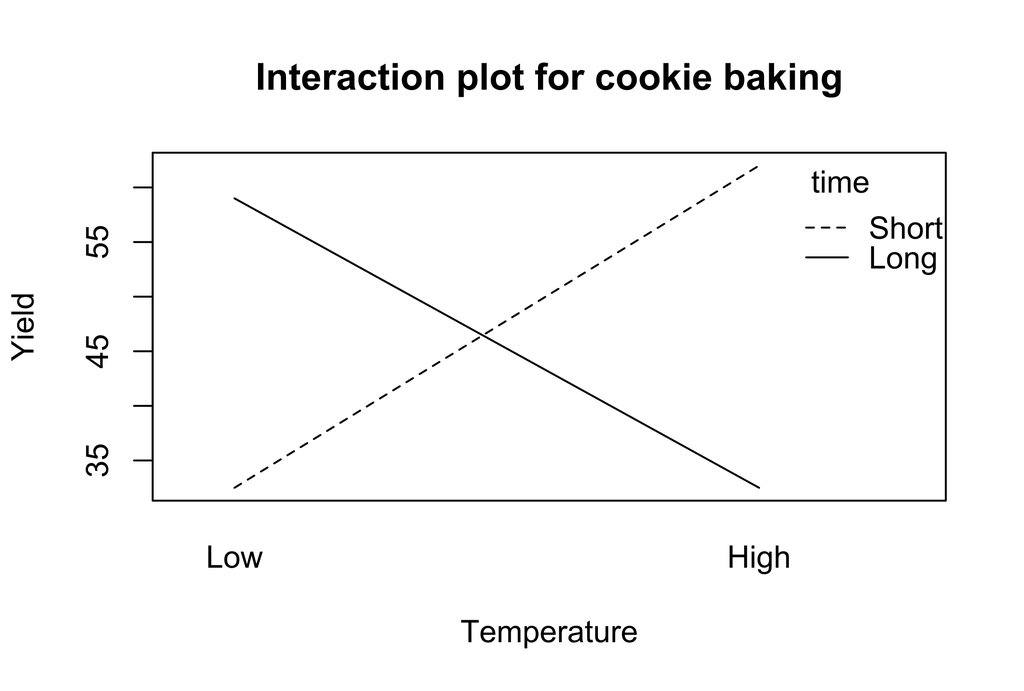

source

## Linear regression: interactions

You can also specify interactions between variables in a formula `y ~ x1 + x2 + x1 * x2`. This allows for not only the intercepts between factors to differ, but also the slopes with regard to the interacting variable.

```r
fit6 <- glm(visits ~ highest_temp + year + age + age*highest_temp, data = er_temps
)
tidy(fit6)
```

```
# A tibble: 11 × 5
   term                         estimate std.error statistic  p.value
   <chr>                           <dbl>     <dbl>     <dbl>    <dbl>
 1 (Intercept)                 -6373.     1716.      -3.71   0.000597
 2 highest_temp                    2.23      2.67     0.836  0.408
 3 year                            3.08      0.853    3.61   0.000809
 4 age35-64 years                 -3.86    380.      -0.0102 0.992
 5 age15-34 years               -142.      380.      -0.373  0.711
 6 age5-14 years                 315.      380.       0.829  0.412
 7 age0-4 years                  369.      447.       0.825  0.414
 8 highest_temp:age35-64 years     0.799     3.76     0.213  0.833
 9 highest_temp:age15-34 years     2.12      3.76     0.564  0.576
10 highest_temp:age5-14 years     -3.39      3.76    -0.903  0.371
11 highest_temp:age0-4 years      -4.04      4.40    -0.918  0.364
```

## Linear regression: interactions

By default, `ggplot` with a factor added as a color will look include the interaction term. Notice the different intercept and slope of the lines.

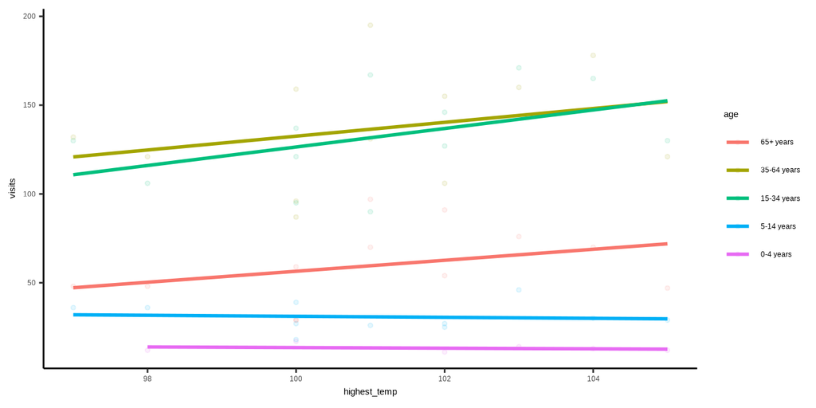

```r
ggplot(er_temps, aes(x = highest_temp, y = visits, color = age)) +
  geom_point(size = 1, alpha = 0.1) +
  geom_smooth(method = "glm", se = FALSE) +
  theme_classic()
```

## Generalized linear models (GLMs)

Generalized linear models (GLMs) allow for fitting regressions for non-continuous/normal outcomes. Examples include: logistic regression, Poisson regression.

Add the `family` argument – a description of the error distribution and link function to be used in the model. These include:

- `binomial(link = "logit")` - outcome is binary
- `poisson(link = "log")` - outcome is count or rate
- others

Very important to use the right test!

See this [case study](https://www.opencasestudies.org/ocs-bp-vaping-case-study/#Data_Analysis) for more information.

See `?family` documentation for details of family functions.

## Logistic regression

Let’s look at a logistic regression example. We’ll use the `er_temps` dataset again.

We will create a new binary variable `high_rate`. We will say a visit rate of more than 8 qualifies as a high visit rate.

```r
er_temps <-
  er_temps |> mutate(high_rate = rate > 8)

glimpse(er_temps)
```

```
Rows: 60
Columns: 9
$ year              <dbl> 2011, 2011, 2011, 2011, 2011, 2012, 2012, 2012, 2012…
$ age               <fct> 0-4 years, 15-34 years, 35-64 years, 5-14 years, 65+…
$ rate              <dbl> 3.523598, 7.344520, 5.840845, 5.197288, 8.341661, 3.…
$ lower95cl         <dbl> 1.820694, 5.946380, 4.800143, 3.499551, 5.981890, 1.…
$ upper95cl         <dbl> 6.155016, 8.742659, 6.881547, 6.895024, 10.701431, 6…
$ visits            <dbl> 12, 106, 121, 36, 48, 12, 130, 121, 29, 47, 17, 121,…
$ highest_temp      <dbl> 98, 98, 98, 98, 98, 105, 105, 105, 105, 105, 100, 10…
$ no_days_above_100 <dbl> 0, 0, 0, 0, 0, 13, 13, 13, 13, 13, 2, 2, 2, 2, 2, 1,…
$ high_rate         <lgl> FALSE, FALSE, FALSE, FALSE, TRUE, FALSE, TRUE, FALSE…
```

## Logistic regression

Let’s explore how `highest_temp`, `year`, and `age` might predict `high_rate`.

```
# General format
glm(y ~ x, data = DATASET_NAME, family = binomial(link = "logit"))
```

```r
binom_fit <- glm(high_rate ~ highest_temp + year + age, data = er_temps, family = binomial(link = "logit"))
summary(binom_fit)
```

```
Call:
glm(formula = high_rate ~ highest_temp + year + age, family = binomial(link = "logit"),
    data = er_temps)

Coefficients:
                Estimate Std. Error z value Pr(>|z|)
(Intercept)    -508.6008   259.3254  -1.961   0.0499 *
highest_temp      0.2187     0.1915   1.142   0.2536
year              0.2412     0.1284   1.878   0.0604 .
age35-64 years   -1.8949     1.0624  -1.784   0.0745 .
age15-34 years    0.8707     0.9537   0.913   0.3613
age5-14 years   -19.7694  3008.3832  -0.007   0.9948
age0-4 years    -19.5166  4117.4125  -0.005   0.9962
---
Signif. codes:  0 '***' 0.001 '**' 0.01 '*' 0.05 '.' 0.1 ' ' 1

(Dispersion parameter for binomial family taken to be 1)

    Null deviance: 64.920  on 52  degrees of freedom
Residual deviance: 36.529  on 46  degrees of freedom
  (7 observations deleted due to missingness)
AIC: 50.529

Number of Fisher Scoring iterations: 18
```

## Logistic Regression

See this [case study](https://www.opencasestudies.org/ocs-bp-vaping-case-study/#Logistic_regression_%E2%80%9Cby_hand%E2%80%9D_and_by_model) for more information.

## Odds ratios

> An odds ratio (OR) is a measure of association between an exposure and an outcome. The OR represents the odds that an outcome will occur given a particular exposure, compared to the odds of the outcome occurring in the absence of that exposure.

Check out [this paper](https://www.ncbi.nlm.nih.gov/pmc/articles/PMC2938757/).

Use `oddsratio(x, y)` from the `epitools()` package to calculate odds ratios.

## Odds ratios

During the years 2012, 2018, 2021, and 2022, there were multiple consecutive days with temperatures above 100 degrees. We will code this as `heatwave`.

```r
library(epitools)

er_temps <-
  er_temps |>
  mutate(heatwave = year %in% c(2012, 2018, 2021, 2022))

glimpse(er_temps)
```

```
Rows: 60
Columns: 10
$ year              <dbl> 2011, 2011, 2011, 2011, 2011, 2012, 2012, 2012, 2012…
$ age               <fct> 0-4 years, 15-34 years, 35-64 years, 5-14 years, 65+…
$ rate              <dbl> 3.523598, 7.344520, 5.840845, 5.197288, 8.341661, 3.…
$ lower95cl         <dbl> 1.820694, 5.946380, 4.800143, 3.499551, 5.981890, 1.…
$ upper95cl         <dbl> 6.155016, 8.742659, 6.881547, 6.895024, 10.701431, 6…
$ visits            <dbl> 12, 106, 121, 36, 48, 12, 130, 121, 29, 47, 17, 121,…
$ highest_temp      <dbl> 98, 98, 98, 98, 98, 105, 105, 105, 105, 105, 100, 10…
$ no_days_above_100 <dbl> 0, 0, 0, 0, 0, 13, 13, 13, 13, 13, 2, 2, 2, 2, 2, 1,…
$ high_rate         <lgl> FALSE, FALSE, FALSE, FALSE, TRUE, FALSE, TRUE, FALSE…
$ heatwave          <lgl> FALSE, FALSE, FALSE, FALSE, FALSE, TRUE, TRUE, TRUE,…
```

## Odds ratios

In this case, we’re calculating the odds ratio for whether a heatwave is associated with having a visit rate greater than 8.

```r
response <- er_temps |> pull(high_rate)
predictor <- er_temps |> pull(heatwave)

oddsratio(predictor, response)
```

```
$data
         Outcome
Predictor FALSE TRUE Total
    FALSE    28    7    35
    TRUE      9    9    18
    Total    37   16    53

$measure
         odds ratio with 95% C.I.
Predictor estimate    lower    upper
    FALSE 1.000000       NA       NA
    TRUE  3.855878 1.113406 14.22934

$p.value
         two-sided
Predictor midp.exact fisher.exact chi.square
    FALSE         NA           NA         NA
    TRUE   0.0331246   0.03178645 0.02425672

$correction
[1] FALSE

attr(,"method")
[1] "median-unbiased estimate & mid-p exact CI"
```

## Odds ratios

The Odds Ratio is 3.86.

When the predictor is TRUE (aka it was a heatwave year), the odds of the response (high hospital visitation) are 3.86 times greater than when it is FALSE (not a heatwave year).

[output not shown]

## Final note

Some final notes:

- Researcher’s responsibility to **understand the statistical method** they use – underlying assumptions, correct interpretation of method results
- Researcher’s responsibility to **understand the R software** they use – meaning of function’s arguments and meaning of function’s output elements

## Summary

- `glm()` fits regression models:
  - Use the `formula =` argument to specify the model (e.g., `y ~ x` or `y ~ x1 + x2` using column names)
  - Use `data =` to indicate the dataset
  - Use `family =` to do a other regressions like logistic, Poisson and more
  - `summary()` gives useful statistics
- `oddsratio()` from the `epitools` package can calculate odds ratios (outside of logistic regression - which allows more than one explanatory variable)
- this is just the tip of the iceberg!

## Resources (also on the [website](https://daseh.org/resources.html)!)

For more check out:

- [this chapter](https://jhudatascience.org/tidyversecourse/model.html#linear-modeling) on modeling in this tidyverse book
- [this chart on when to do what test](https://www.scribbr.com/statistics/statistical-tests/)
- opencasestudies.org

Content for similar topics as this course can also be found on Leanpub.

## Lab Part 2

🏠 [Class Website](https://daseh.org/)

💻 [Lab](https://daseh.org/modules/Statistics/lab/Statistics_Lab.Rmd)

📃 [Day 8 Cheatsheet](https://daseh.org/modules/cheatsheets/Day-8.pdf)

Image by [Gerd Altmann](https://pixabay.com/users/geralt-9301/?utm_source=link-attribution&utm_medium=referral&utm_campaign=image&utm_content=812226) from [Pixabay](https://pixabay.com//?utm_source=link-attribution&utm_medium=referral&utm_campaign=image&utm_content=812226)

## Extra Slides

## Wilcoxon Test

The Wilcoxon test is a good alternative to the t-test when the normal distribution of the differences between paired individuals cannot be assumed.

`wilcox.test(x, y, ..)`

- Like t-test, provide one or two vectors (x, y)
- Choose from `alternative = c("two.sided", "less", "greater")`
- Use `paired = TRUE` for paired values (e.g., before and after)

## Shapiro Test

Can tell you if a vector is normally distributed.

`shapiro.test(x)`

The smaller the p-value, the more likely the data violates normality assumptions.

## Kolmogorov-Smirnov test

Can tell you if two groups come from different distributions.

`ks.test()`

The smaller the p-value, the more likely the data are from different distributions.

## Fisher’s F-Test

Performs an F test to compare the variances of two samples from normal populations.

`var.test()`

## Chi-squared test

For categorical data/ratios, can tell you if observations match expected values or if two categorical variables are independent.

`chisq.test()`

## Analysis of Variance (ANOVA)

For balanced designs, determine if multiple variables influence a dependent variable. “Within versus among group variance”.

`aov()`